# Machine Learning I Group Work

Adriana Ricklin, Yvonne Schaerli, Christina Sudermann, Carole Mattmann

11 June 2020

# 1 Packages

The following packages are used in the analysis:

```r
library(gridExtra)
library(tree)     #for decision trees
library(dplyr)
library(readr)
library(randomForest) #for decision trees
library(e1071)     # for SVM
library(ISLR)
library(tibble)
library(MASS)
library(gbm)
library(ipred)
library(Metrics)
library(neuralnet) # for NN
library(h2o)       # for NN
library(bit64)     # for NN
library(tidyverse) # includes ggplot2
library(mgcv)      # for GAM
```

# 2 Import and data cleaning

The dataset “insurance” from https://www.kaggle.com/mirichoi0218/insurance is imported and transformed. The data contains information about 1338 people, their health care charges and further parameters such as age, number of children they have etc.

```r
#getwd()
#setwd("~/GitHub/machinelearning/machinelearning/03_rmarkdown") #adrianas extrawurst
insurance <- read.csv("../01_data/insurance.csv", header=TRUE)
str(insurance)
```

```
## 'data.frame':    1338 obs. of  7 variables:
##  $ age     : int  19 18 28 33 32 31 46 37 37 60 ...
##  $ sex     : Factor w/ 2 levels "female","male": 1 2 2 2 2 1 1 1 2 1 ...
##  $ bmi     : num  27.9 33.8 33 22.7 28.9 ...
##  $ children: int  0 1 3 0 0 0 1 3 2 0 ...
##  $ smoker  : Factor w/ 2 levels "no","yes": 2 1 1 1 1 1 1 1 1 1 ...
##  $ region  : Factor w/ 4 levels "northeast","northwest",..: 4 3 3 2 2 3 3 2 1 2 ...
##  $ charges : num  16885 1726 4449 21984 3867 ...
```

```r
# smoker = 1 / nonsmoker = 0
insurance$smoker <- as.character(insurance$smoker)
insurance$smoker[insurance$smoker == "yes"] <- "1"
insurance$smoker[insurance$smoker == "no"] <- "0"
insurance$smoker <- as.factor(insurance$smoker)
# female = 1 / male = 0
insurance$sex <- as.character(insurance$sex)
insurance$sex[insurance$sex == "female"] <- "1"
insurance$sex[insurance$sex == "male"] <- "0"
insurance$sex <- as.factor(insurance$sex)
# region / SE = 1 / SW = 0 / NE = 2 / NW = 3
insurance$region <- as.character(insurance$region)
insurance$region[insurance$region == "southwest"] <- "1"
insurance$region[insurance$region == "southeast"] <- "0"
insurance$region[insurance$region == "northeast"] <- "2"
insurance$region[insurance$region == "northwest"] <- "3"
insurance$region <- as.factor(insurance$region)
head(insurance)
```

```
##   age sex    bmi children smoker region   charges
## 1  19   1 27.900        0      1      1 16884.924
## 2  18   0 33.770        1      0      0  1725.552
## 3  28   0 33.000        3      0      0  4449.462
## 4  33   0 22.705        0      0      3 21984.471
## 5  32   0 28.880        0      0      3  3866.855
## 6  31   1 25.740        0      0      0  3756.622
```

# 3 Linear models

The data set used for this project contains 1338 observations and seven variables containing the age, sex, bmi, children, smoker, region and charges. Those variables are covering continuous and categorical variables. The region as an categorical variable is covering four different levels: southeast (0), southwest (1), northeast (2) and northwest (3).

## 3.1 Basic analysis of continuous variables

We will begin with a graphical analysis. We will plot the response variable against the given predictors to gather first relationships, which can be used later in the modelling process.

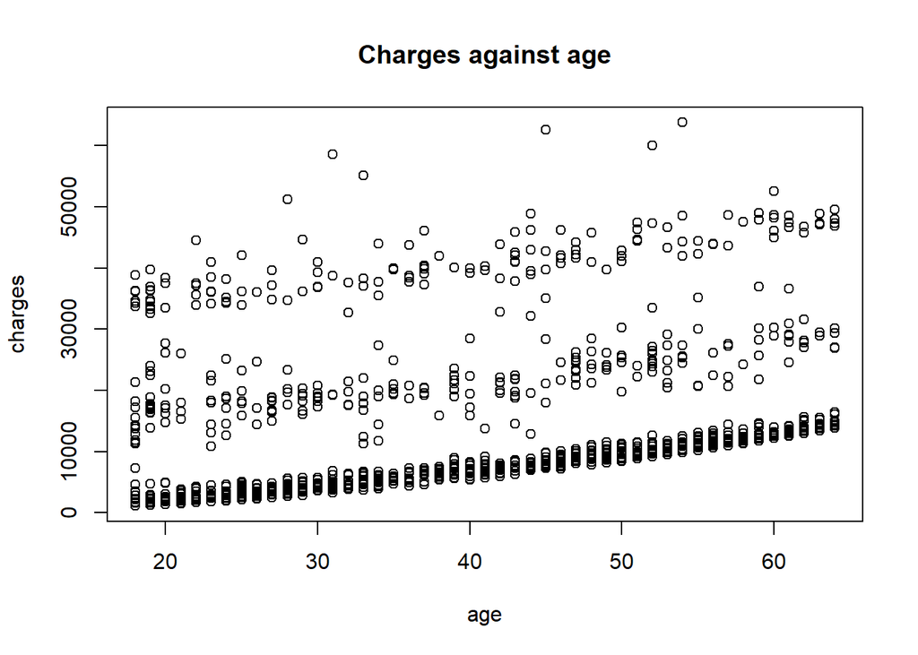

```r
plot(charges ~ age, data =insurance, main = 'Charges against age')
```

There seems to be a positive relationship between age and charges as can be seen by the seemingly positive relationship between ages and charges.

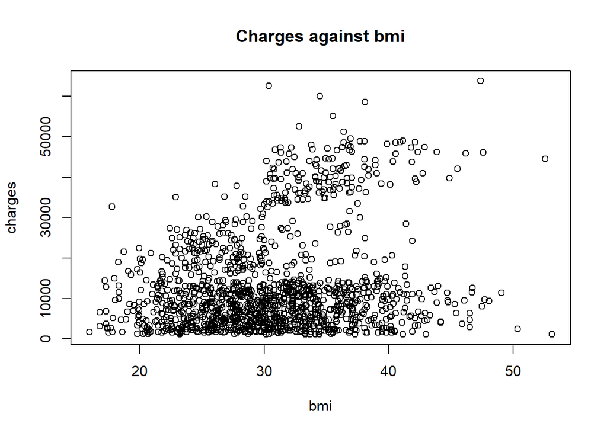

```r
plot(charges ~ bmi, data =insurance, main = 'Charges against bmi')
```

The above plot is not showing a clear linear relationship between bmi and the corresponding charges.

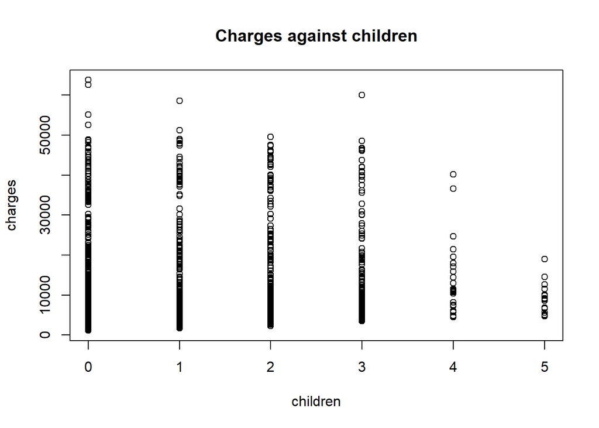

```r
plot(charges ~ children, data =insurance, main = 'Charges against children')
```

There might be a connection between the number of children and charges. As shown above, it might be possible to interpret that with a rising number of children the charges are decreasing. Still, this is not a clear relationship, more a wide interpretation of the plot. Not taken into consideration has been the number of participants per group, meaning that our interpretation of the plot leaves out that there are much more people with 0 children than there are with 4 or 5.

## 3.2 Basic analysis of categorical variables

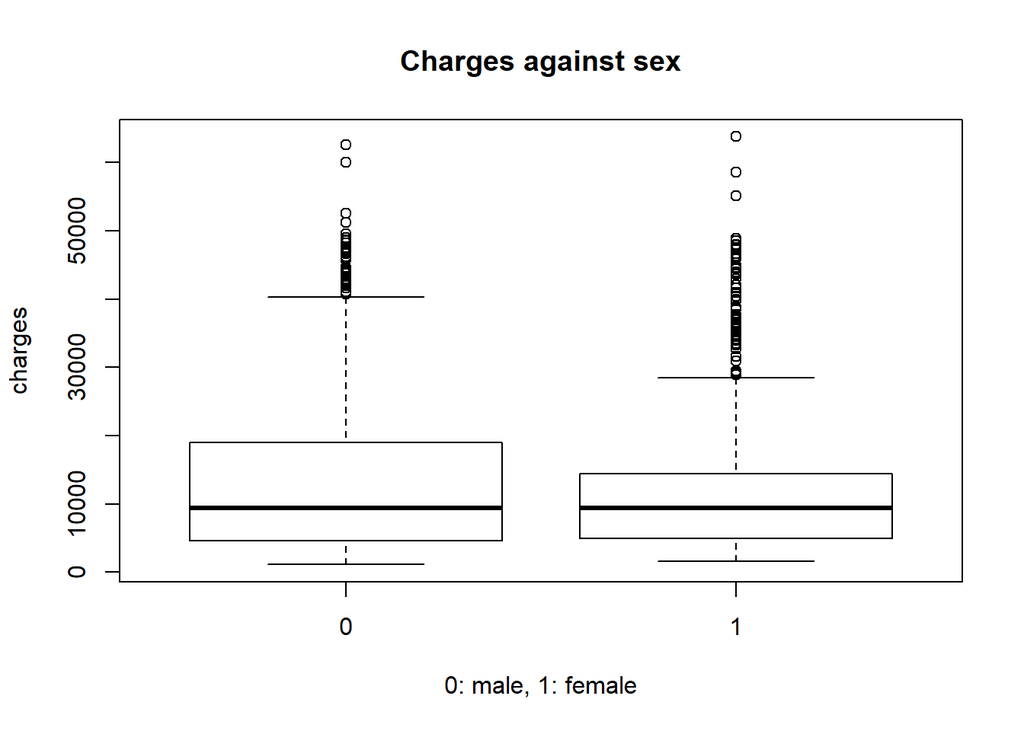

```r
plot(charges ~ sex, data =insurance, xlab = "0: male, 1: female",  main = 'Charges against sex')
```

As shown above there are some differences in the charges, comparing the boxplot for the two given genders, whereas 0 stands for male, 1 stands for female. It seems that the range for 50% of the male observations is bigger than the one for the female group, meaning the distribution for males is broader than the one for females. Also the upper whisker is about 10’000 lower than the same for the male group.

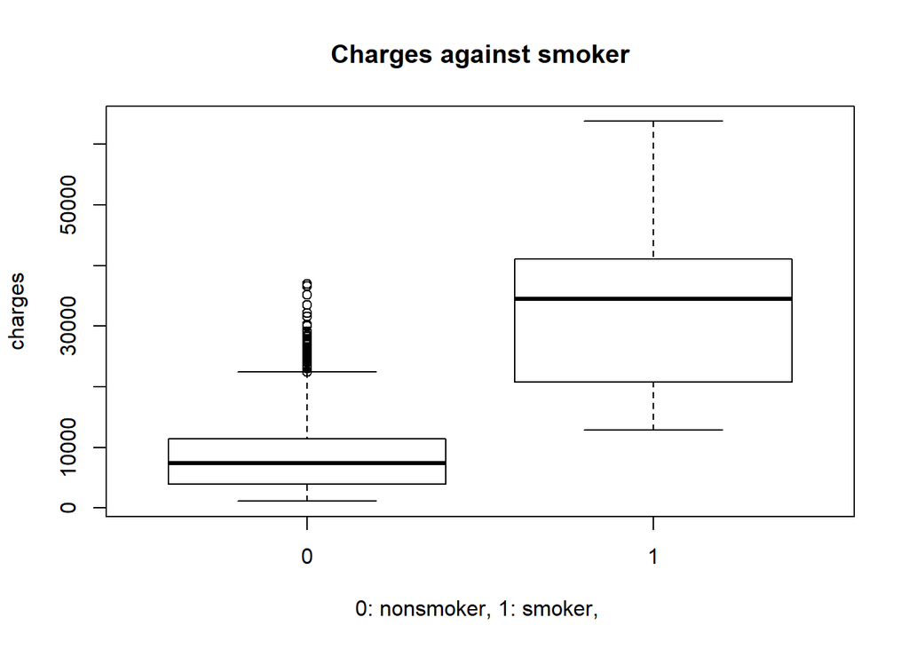

```r
plot(charges ~ smoker, data =insurance, xlab = "0: nonsmoker, 1: smoker, ", main = 'Charges against smoker')
```

This plot is showing a clear effect of smoking on the charges. As one can see, people who are not smoking (value = 0) have mean charges that are three times lower than the charges for smokers (value = 1). Even the outliers of the non-smokers are still within the range of the upper boxplot quartil of the smokers.

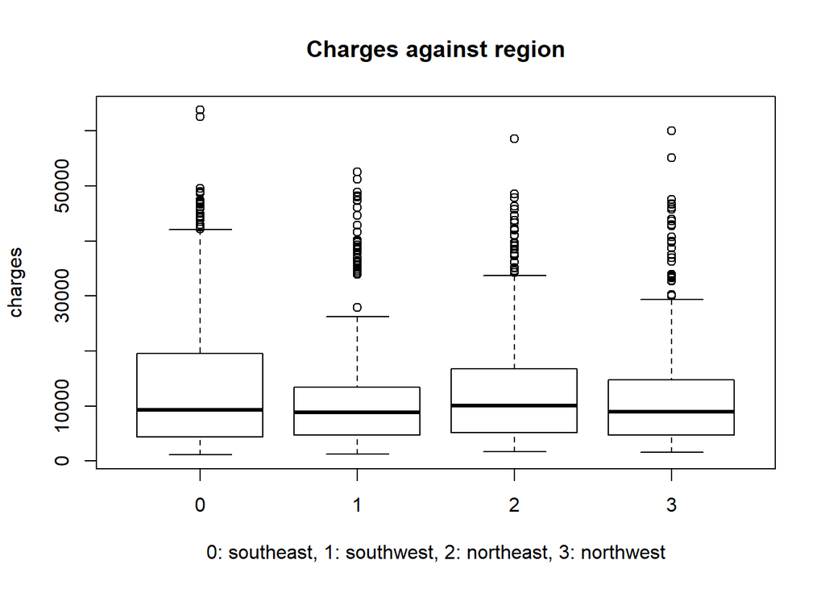

```r
plot(charges ~ region, data =insurance, xlab = "0: southeast, 1: southwest, 2: northeast, 3: northwest", main = 'Charges against region')
```

In this case, there seems not to be any clear relationship or trend visible between region and charges. Comparing the four regions with each other, it seems that there are slightly small differences between the width of the boxes, distribution of 50% of the observation as well the setting of the upper whisker. Those differences will be analysed later.

## 3.3 Basic analysis of categorical and continuous variables

In this part we want to show exemplary how the relationship between charges and age can be affected by adding a categorical variable. This can be used for further data explorations and can be adapted on all other variables. For this section, we will just perform this enlargement for the case of the age to illustrate some possible relationships, which also can be helpful for the following modelling process.

First, we add the variable “sex” to charges against age.

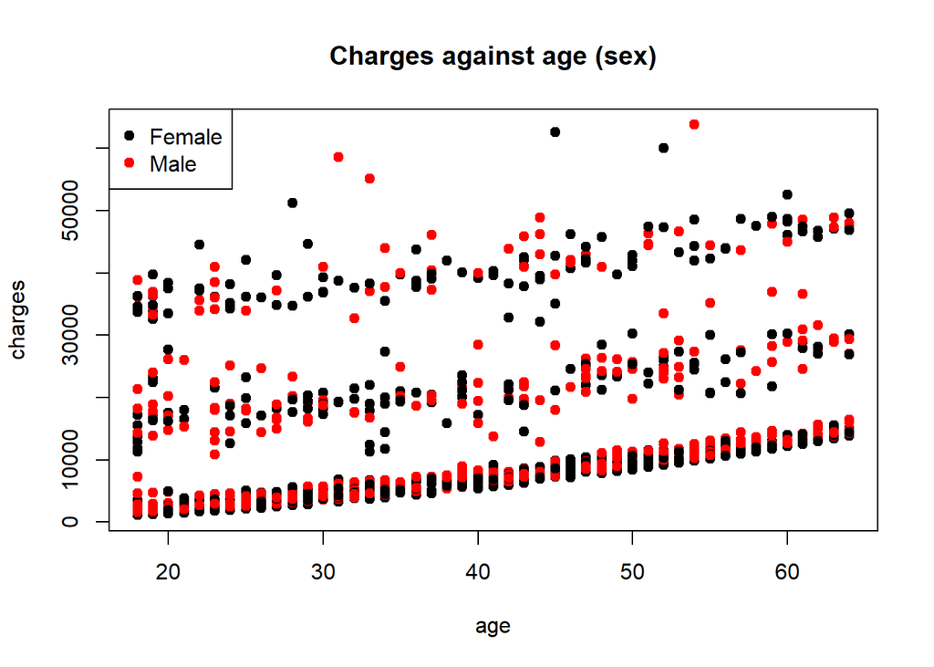

```r
plot(charges ~ age, data = insurance,
     col = sex,
     pch = 19,
     main = "Charges against age (sex)")
legend( "topleft",
        pch = 19,
        legend = c("Female", "Male"),
        col = c("black", "red"))
```

Also, we go a different approach and change the variable sex to variable smoker:

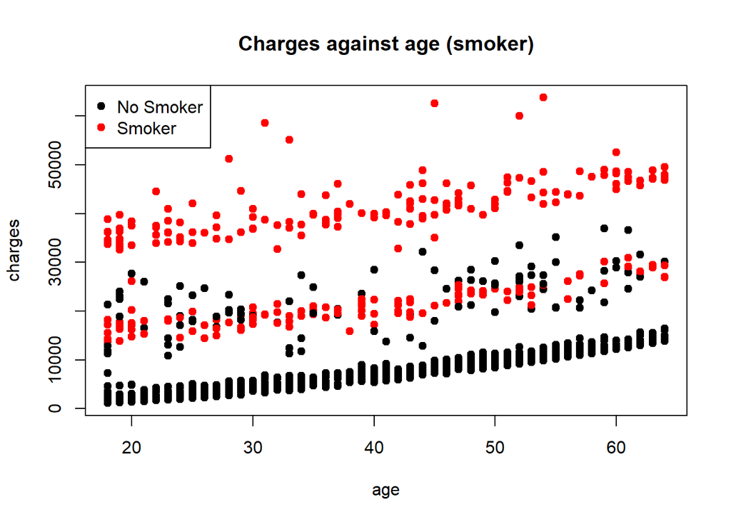

```r
plot(charges ~ age, data = insurance,
     col = smoker,
     pch = 19,
     main = "Charges against age (smoker)")
legend( "topleft",
        pch = 19,
        legend = c("No Smoker", "Smoker"),
        col = c("black", "red"))
```

Last but not least, we also try to fit “regions” to charges against age

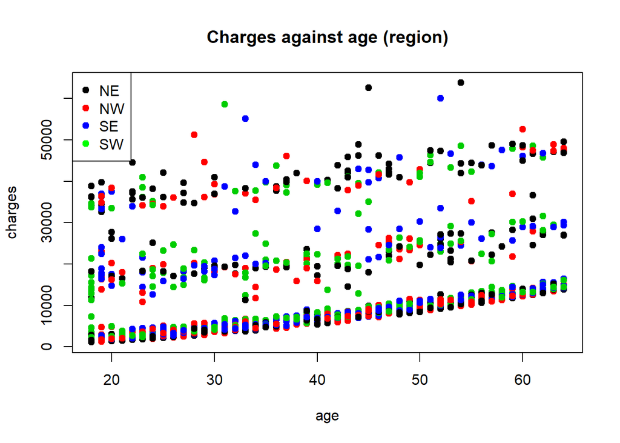

```r
plot(charges ~ age, data = insurance,
     col = region,
     pch = 19,
     main = "Charges against age (region)")
legend( "topleft",
        pch = 19,
        legend = c("NE", "NW","SE","SW"),
        col = c("black", "red" ,"blue" , "green"))
```

Since it is possible to have overlapping observations, we will plot the same set-up using the qplot. Having separate facets will avoid overlapping and therefore might serve different results as already seen above.

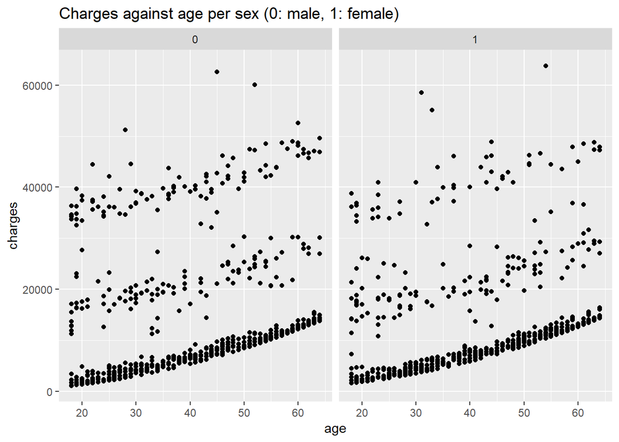

```r
qplot(y=charges, x=age,
      main = "Charges against age per sex (0: male, 1: female)",
      data = insurance,
      facets = ~ sex
      )
```

```r
lm.insurance <- lm(charges ~ age, data = insurance)
```

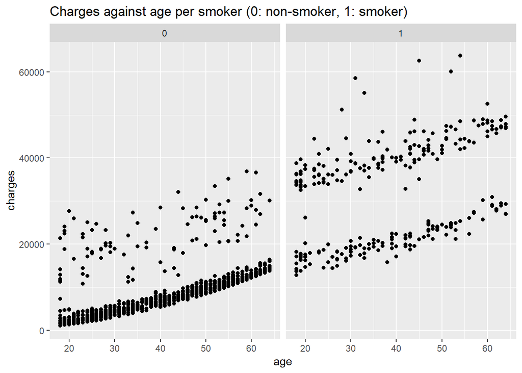

```r
qplot(y=charges, x=age,
      main = "Charges against age per smoker (0: non-smoker, 1: smoker)",
      data = insurance,
      facets = ~ smoker)
```

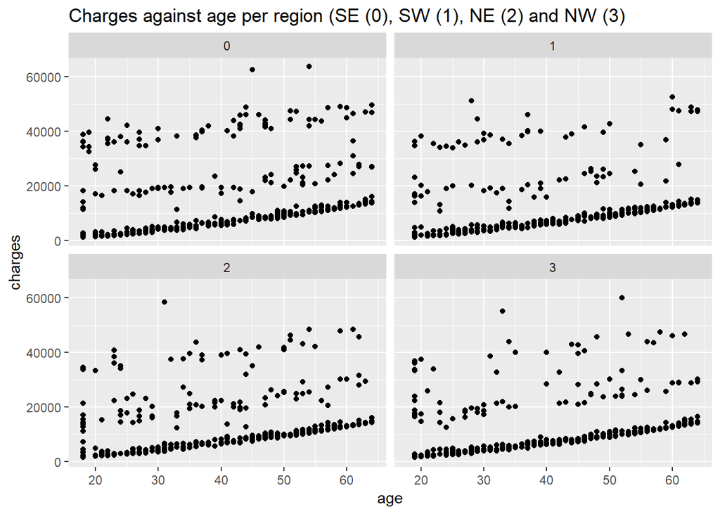

```r
qplot(y=charges, x=age,
      data = insurance,
      main = "Charges against age per region (SE (0), SW (1), NE (2) and NW (3)",
      facets = ~ region)
```

## 3.4 Fitting a first Linear Model

As usual, we will start by fitting a simple regression model to the insurance dataset. Therefore we will start with one variable and add additional complexity in each following subset. This step-by-step approach helps to explore the data slightly better and will simplify the final modelling.

### 3.4.1 Linear Model with one variable

For the first simple regression model we will use the age.

```r
lm.insurance <- lm(charges ~ age, data = insurance)
summary(lm.insurance)
```

```
##
## Call:
## lm(formula = charges ~ age, data = insurance)
##
## Residuals:
##    Min     1Q Median     3Q    Max
##  -8059  -6671  -5939   5440  47829
##
## Coefficients:
##             Estimate Std. Error t value Pr(>|t|)
## (Intercept)   3165.9      937.1   3.378 0.000751 ***
## age            257.7       22.5  11.453  < 2e-16 ***
## ---
## Signif. codes:  0 '***' 0.001 '**' 0.01 '*' 0.05 '.' 0.1 ' ' 1
##
## Residual standard error: 11560 on 1336 degrees of freedom
## Multiple R-squared:  0.08941,    Adjusted R-squared:  0.08872
## F-statistic: 131.2 on 1 and 1336 DF,  p-value: < 2.2e-16
```

#### 3.4.1.1 Coefficient and Interpretation

As shown in the R Output a person with the age of 0 will have a base charge of 3165.885. This intercept and its interpretation seems to be nonsensical, thus one needs to pay attention in what extend this model can be applied.

With each year, charges increase by 257.7226, which is the slope for the regression line.

#### 3.4.1.2 P-values

With a value of 2e-16, age seems to have a very strong effect on charges. This means that the slope of charges is not flat, and the hypothesis of being zero has to be denied.

#### 3.4.1.3 Including the gender as a second variable

In this subset, we will consider also the sex for modelling a simple regression model.

```r
lm.insurance.2 <- lm(charges ~ age + sex, data = insurance)
summary(lm.insurance.2)
```

```
##
## Call:
## lm(formula = charges ~ age + sex, data = insurance)
##
## Residuals:
##    Min     1Q Median     3Q    Max
##  -8821  -6947  -5511   5443  48203
##
## Coefficients:
##             Estimate Std. Error t value Pr(>|t|)
## (Intercept)  3882.46     980.49   3.960  7.9e-05 ***
## age           258.87      22.47  11.523  < 2e-16 ***
## sex1        -1538.83     631.08  -2.438   0.0149 *
## ---
## Signif. codes:  0 '***' 0.001 '**' 0.01 '*' 0.05 '.' 0.1 ' ' 1
##
## Residual standard error: 11540 on 1335 degrees of freedom
## Multiple R-squared:  0.09344,    Adjusted R-squared:  0.09209
## F-statistic:  68.8 on 2 and 1335 DF,  p-value: < 2.2e-16
```

As the output shows the additionally added variable of sex with a calculated p-value of 0.0149 seems to have an effect on charges and therefore should be considered within the modelling process.

#### 3.4.1.4 Including interaction

Since a second variable was added, we want to explore if there might be significant interactions between age and sex, that might have to be considered for the modelling process.

```r
lm.insurance.3 <-lm(charges ~ age * sex, data =insurance)
summary(lm.insurance.3)
```

```
##
## Call:
## lm(formula = charges ~ age * sex, data = insurance)
##
## Residuals:
##    Min     1Q Median     3Q    Max
##  -8823  -6936  -5500   5456  48187
##
## Coefficients:
##             Estimate Std. Error t value Pr(>|t|)
## (Intercept)  3811.77    1308.29   2.914  0.00363 **
## age           260.68      31.62   8.244 3.96e-16 ***
## sex1        -1394.92    1872.30  -0.745  0.45638
## age:sex1       -3.67      44.95  -0.082  0.93494
## ---
## Signif. codes:  0 '***' 0.001 '**' 0.01 '*' 0.05 '.' 0.1 ' ' 1
##
## Residual standard error: 11540 on 1334 degrees of freedom
## Multiple R-squared:  0.09345,    Adjusted R-squared:  0.09141
## F-statistic: 45.84 on 3 and 1334 DF,  p-value: < 2.2e-16
```

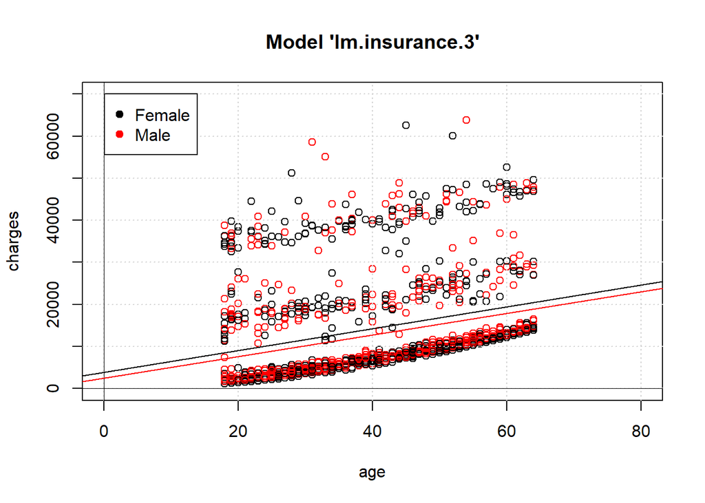

```r
plot(charges ~ age, data =insurance,
     main = "Model 'lm.insurance.3'",
     xlim = c(0, 80),
     ylim = c(0, 70000),
     col = sex)
##
grid()
##
abline(h = 0, lwd = 0.5)
abline(v = 0, lwd = 0.5)
##
abline(a = coef(lm.insurance.3)[1],
       b = coef(lm.insurance.3)["age"])
abline(a = coef(lm.insurance.3)[1] + coef(lm.insurance.3)["sex1"] ,
       b = coef(lm.insurance.3)["age"] + coef(lm.insurance.3)["age:sex1"],
       col = "red")
legend(x = 0.1, y = 70000,
       pch = 19,
       legend = c("Female","Male"),
       col = c("black", "red"))
```

```r
coef(lm.insurance.3)
```

```
##  (Intercept)          age         sex1     age:sex1
##  3811.773852   260.681339 -1394.925331    -3.669849
```

```r
summary(lm.insurance.3)$coefficients
```

```
##                 Estimate Std. Error     t value     Pr(>|t|)
## (Intercept)  3811.773852 1308.29248  2.91354869 3.633010e-03
## age           260.681339   31.62249  8.24354130 3.958052e-16
## sex1        -1394.925331 1872.29663 -0.74503437 4.563822e-01
## age:sex1       -3.669849   44.95054 -0.08164194 9.349437e-01
```

The R-output shows that there isn’t any significant interaction between age and sex that has to be considered in our model.

## 3.5 Final Linear Model Development

In this section we want to find an appropriate model, which accounts all relevant parameters and interactions. Afterwards we will then compare the fitted model with a base model and test its performance.

### 3.5.1 Linear Model with all variables

```r
lm.insurance.all <- lm(charges ~ age + sex + bmi + children + smoker + region , data = insurance)
summary(lm.insurance.all)
```

```
##
## Call:
## lm(formula = charges ~ age + sex + bmi + children + smoker +
##     region, data = insurance)
##
## Residuals:
##      Min       1Q   Median       3Q      Max
## -11304.9  -2848.1   -982.1   1393.9  29992.8
##
## Coefficients:
##              Estimate Std. Error t value Pr(>|t|)
## (Intercept) -13104.87    1090.51 -12.017  < 2e-16 ***
## age            256.86      11.90  21.587  < 2e-16 ***
## sex1           131.31     332.95   0.394 0.693348
## bmi            339.19      28.60  11.860  < 2e-16 ***
## children       475.50     137.80   3.451 0.000577 ***
## smoker1      23848.53     413.15  57.723  < 2e-16 ***
## region1         74.97     470.64   0.159 0.873460
## region2       1035.02     478.69   2.162 0.030782 *
## region3        682.06     478.96   1.424 0.154669
## ---
## Signif. codes:  0 '***' 0.001 '**' 0.01 '*' 0.05 '.' 0.1 ' ' 1
##
## Residual standard error: 6062 on 1329 degrees of freedom
## Multiple R-squared:  0.7509, Adjusted R-squared:  0.7494
## F-statistic: 500.8 on 8 and 1329 DF,  p-value: < 2.2e-16
```

As the above R Output shows, not every variable seems to have a significant effect on the charges. Therefore we will separately test the variables of sex and region before dropping them from our model.

#### 3.5.1.1 Testing sex before dropping

Before we remove the variable sex from our model we will first make a deeper analysis.

```r
lm.sex <- lm(charges ~ sex, data=insurance)
summary(lm.sex)
```

```
##
## Call:
## lm(formula = charges ~ sex, data = insurance)
##
## Residuals:
##    Min     1Q Median     3Q    Max
## -12835  -8435  -3980   3476  51201
##
## Coefficients:
##             Estimate Std. Error t value Pr(>|t|)
## (Intercept)  13956.8      465.2  30.003   <2e-16 ***
## sex1         -1387.2      661.3  -2.098   0.0361 *
## ---
## Signif. codes:  0 '***' 0.001 '**' 0.01 '*' 0.05 '.' 0.1 ' ' 1
##
## Residual standard error: 12090 on 1336 degrees of freedom
## Multiple R-squared:  0.003282,   Adjusted R-squared:  0.002536
## F-statistic:   4.4 on 1 and 1336 DF,  p-value: 0.03613
```

```r
coef(lm.sex)
```

```
## (Intercept)        sex1
##   13956.751   -1387.172
```

#### 3.5.1.2 Testing region before dropping

```r
lm.region.1 <- lm(charges ~ region, data = insurance)
aggregate(charges ~ region, FUN = mean, data =insurance)
```

```
##   region  charges
## 1      0 14735.41
## 2      1 12346.94
## 3      2 13406.38
## 4      3 12417.58
```

```r
summary(lm.region.1)
```

```
##
## Call:
## lm(formula = charges ~ region, data = insurance)
##
## Residuals:
##    Min     1Q Median     3Q    Max
## -13614  -8463  -3793   3385  49035
##
## Coefficients:
##             Estimate Std. Error t value Pr(>|t|)
## (Intercept)  14735.4      633.3  23.266   <2e-16 ***
## region1      -2388.5      922.2  -2.590   0.0097 **
## region2      -1329.0      922.9  -1.440   0.1501
## region3      -2317.8      922.2  -2.513   0.0121 *
## ---
## Signif. codes:  0 '***' 0.001 '**' 0.01 '*' 0.05 '.' 0.1 ' ' 1
##
## Residual standard error: 12080 on 1334 degrees of freedom
## Multiple R-squared:  0.006634,   Adjusted R-squared:  0.0044
## F-statistic:  2.97 on 3 and 1334 DF,  p-value: 0.03089
```

```r
lm.region.0 <- lm(charges ~ 1 , data = insurance)
coef(lm.region.0)
```

```
## (Intercept)
##    13270.42
```

```r
anova(lm.region.0, lm.region.1)
```

```
## Analysis of Variance Table
##
## Model 1: charges ~ 1
## Model 2: charges ~ region
##   Res.Df        RSS Df  Sum of Sq      F  Pr(>F)
## 1   1337 1.9607e+11
## 2   1334 1.9477e+11  3 1300759681 2.9696 0.03089 *
## ---
## Signif. codes:  0 '***' 0.001 '**' 0.01 '*' 0.05 '.' 0.1 ' ' 1
```

The anova test shows low evidence that the model with more parameters(in this case only the region) fits better to the data. The F-value seems to be very small and also the p-value is not highly significant with 0.03089. Anyhow there is a drop in the RSS, by adding 3 additional parameters of the different regions. To have a better understanding, we can additionally perform posthoc contrasts to decide afterwards if we will drop region finally from our model. Before performing several posthoc test and repeating this exercise to all possible combinations we will use the ggplot to explore the data quickly upfront.

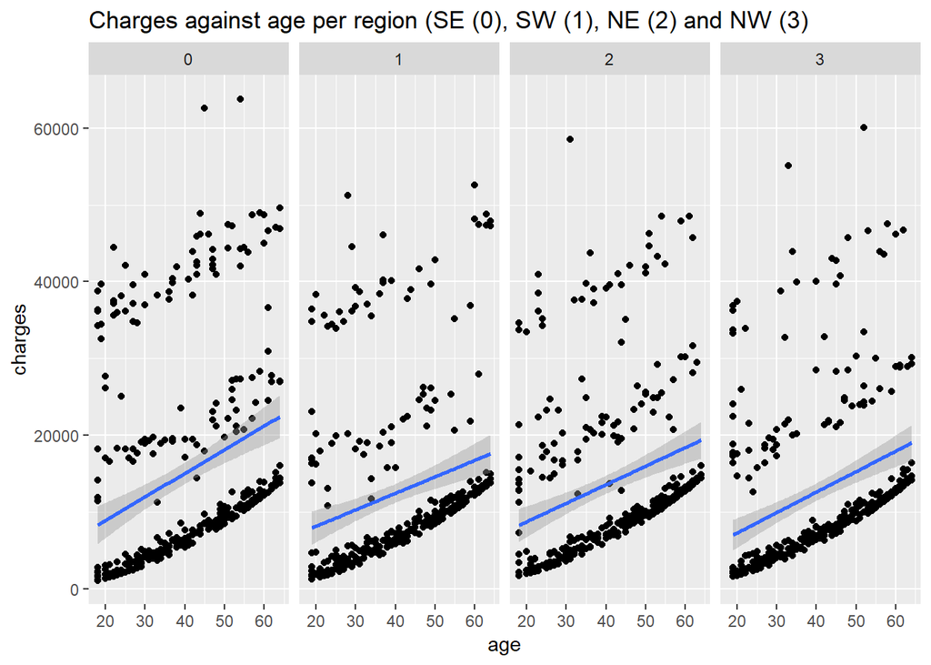

```r
ggplot(data=insurance,
       mapping = aes(y = charges, x= age))+ geom_point()+geom_smooth(method = 'lm') + facet_grid(. ~region) +
  ggtitle("Charges against age per region (SE (0), SW (1), NE (2) and NW (3)")
```

Using the visualization, it seems that there seems to be no obvious difference and effect. Therefore, we decide to drop also the variable region from our linear model.

### 3.5.2 Dropping variables from the model

```r
drop1(lm.insurance.all, test="F")
```

```
## Single term deletions
##
## Model:
## charges ~ age + sex + bmi + children + smoker + region
##          Df  Sum of Sq        RSS   AIC   F value    Pr(>F)
## <none>                 4.8840e+10 23316
## age       1 1.7124e+10 6.5964e+10 23717  465.9837 < 2.2e-16 ***
## sex       1 5.7164e+06 4.8845e+10 23315    0.1556  0.693348
## bmi       1 5.1692e+09 5.4009e+10 23449  140.6627 < 2.2e-16 ***
## children  1 4.3755e+08 4.9277e+10 23326   11.9063  0.000577 ***
## smoker    1 1.2245e+11 1.7129e+11 24993 3331.9680 < 2.2e-16 ***
## region    3 2.3343e+08 4.9073e+10 23317    2.1173  0.096221 .
## ---
## Signif. codes:  0 '***' 0.001 '**' 0.01 '*' 0.05 '.' 0.1 ' ' 1
```

```r
lm.insurance.1 <- update(lm.insurance.all, .~. -region -sex)
formula(lm.insurance.1)
```

```
## charges ~ age + bmi + children + smoker
```

```r
summary(lm.insurance.1)
```

```
##
## Call:
## lm(formula = charges ~ age + bmi + children + smoker, data = insurance)
##
## Residuals:
##      Min       1Q   Median       3Q      Max
## -11897.9  -2920.8   -986.6   1392.2  29509.6
##
## Coefficients:
##              Estimate Std. Error t value Pr(>|t|)
## (Intercept) -12102.77     941.98 -12.848  < 2e-16 ***
## age            257.85      11.90  21.675  < 2e-16 ***
## bmi            321.85      27.38  11.756  < 2e-16 ***
## children       473.50     137.79   3.436 0.000608 ***
## smoker1      23811.40     411.22  57.904  < 2e-16 ***
## ---
## Signif. codes:  0 '***' 0.001 '**' 0.01 '*' 0.05 '.' 0.1 ' ' 1
##
## Residual standard error: 6068 on 1333 degrees of freedom
## Multiple R-squared:  0.7497, Adjusted R-squared:  0.7489
## F-statistic: 998.1 on 4 and 1333 DF,  p-value: < 2.2e-16
```

Comparing the summary output of lm.insurance.0 and lm.insurance.1, the latest model is only including variables with a p-value indicating a significant factor.

### 3.5.3 Considering Interactions

```r
drop1(lm.insurance.1, test="F")
```

```
## Single term deletions
##
## Model:
## charges ~ age + bmi + children + smoker
##          Df  Sum of Sq        RSS   AIC  F value    Pr(>F)
## <none>                 4.9078e+10 23315
## age       1 1.7297e+10 6.6375e+10 23717  469.789 < 2.2e-16 ***
## bmi       1 5.0884e+09 5.4167e+10 23445  138.203 < 2.2e-16 ***
## children  1 4.3477e+08 4.9513e+10 23325   11.809 0.0006077 ***
## smoker    1 1.2345e+11 1.7253e+11 24995 3352.911 < 2.2e-16 ***
## ---
## Signif. codes:  0 '***' 0.001 '**' 0.01 '*' 0.05 '.' 0.1 ' ' 1
```

```r
lm.insurance.2 <- update(lm.insurance.1, .~. +age:bmi + age:children + age:smoker + bmi:children + bmi:smoker + children:smoker)
summary(lm.insurance.2)
```

```
##
## Call:
## lm(formula = charges ~ age + bmi + children + smoker + age:bmi +
##     age:children + age:smoker + bmi:children + bmi:smoker + children:smoker,
##     data = insurance)
##
## Residuals:
##      Min       1Q   Median       3Q      Max
## -13996.3  -1947.6  -1331.5   -406.4  29570.2
##
## Coefficients:
##                    Estimate Std. Error t value Pr(>|t|)
## (Intercept)      -6.745e+02  2.106e+03  -0.320    0.749
## age               2.055e+02  4.963e+01   4.140  3.7e-05 ***
## bmi              -6.339e+01  6.756e+01  -0.938    0.348
## children          6.957e+02  6.341e+02   1.097    0.273
## smoker1          -1.983e+04  1.861e+03 -10.651  < 2e-16 ***
## age:bmi           1.912e+00  1.561e+00   1.225    0.221
## age:children      1.201e+00  8.527e+00   0.141    0.888
## age:smoker1      -9.141e-01  2.384e+01  -0.038    0.969
## bmi:children     -5.334e+00  1.863e+01  -0.286    0.775
## bmi:smoker1       1.437e+03  5.317e+01  27.029  < 2e-16 ***
## children:smoker1 -3.858e+02  2.841e+02  -1.358    0.175
## ---
## Signif. codes:  0 '***' 0.001 '**' 0.01 '*' 0.05 '.' 0.1 ' ' 1
##
## Residual standard error: 4874 on 1327 degrees of freedom
## Multiple R-squared:  0.8392, Adjusted R-squared:  0.838
## F-statistic: 692.8 on 10 and 1327 DF,  p-value: < 2.2e-16
```

As the above output shows, not all of the added interactions have to be considered in the model. Upfront we also tried to generate a linear model including all possible interactions. Since the output was not satisfying we skipped this analysis at this point. Therefore, the working assumption in this step was quite easy by editing only possible and simple interactions. Based on the results we will now drop the unnecessary interactions.

```r
drop1(lm.insurance.2, test="F")
```

```
## Single term deletions
##
## Model:
## charges ~ age + bmi + children + smoker + age:bmi + age:children +
##     age:smoker + bmi:children + bmi:smoker + children:smoker
##                 Df  Sum of Sq        RSS   AIC  F value Pr(>F)
## <none>                        3.1519e+10 22735
## age:bmi          1 3.5624e+07 3.1555e+10 22734   1.4998 0.2209
## age:children     1 4.7151e+05 3.1520e+10 22733   0.0199 0.8880
## age:smoker       1 3.4909e+04 3.1519e+10 22733   0.0015 0.9694
## bmi:children     1 1.9467e+06 3.1521e+10 22733   0.0820 0.7747
## bmi:smoker       1 1.7353e+10 4.8872e+10 23319 730.5705 <2e-16 ***
## children:smoker  1 4.3796e+07 3.1563e+10 22734   1.8439 0.1747
## ---
## Signif. codes:  0 '***' 0.001 '**' 0.01 '*' 0.05 '.' 0.1 ' ' 1
```

```r
lm.insurance.3 <- update(lm.insurance.2, .~. -age:bmi - age:children - age:smoker - bmi:children -children:smoker)
summary(lm.insurance.3)
```

```
##
## Call:
## lm(formula = charges ~ age + bmi + children + smoker + bmi:smoker,
##     data = insurance)
##
## Residuals:
##      Min       1Q   Median       3Q      Max
## -14598.6  -1924.4  -1321.4   -465.6  29892.4
##
## Coefficients:
##               Estimate Std. Error t value Pr(>|t|)
## (Intercept)  -2729.002    831.270  -3.283  0.00105 **
## age            264.948      9.553  27.735  < 2e-16 ***
## bmi              5.656     24.873   0.227  0.82014
## children       508.924    110.615   4.601 4.61e-06 ***
## smoker1     -20194.709   1654.505 -12.206  < 2e-16 ***
## bmi:smoker1   1433.788     52.823  27.143  < 2e-16 ***
## ---
## Signif. codes:  0 '***' 0.001 '**' 0.01 '*' 0.05 '.' 0.1 ' ' 1
##
## Residual standard error: 4871 on 1332 degrees of freedom
## Multiple R-squared:  0.8388, Adjusted R-squared:  0.8382
## F-statistic:  1387 on 5 and 1332 DF,  p-value: < 2.2e-16
```

After considering also the interaction between bmi and smoker, which seems to be significant with a small p-value of 2e-16. The variable bmi itself has now a p-value of 0.82014. Therefore let’s have a look on the relationship between bmi and smoker to have a better understanding:

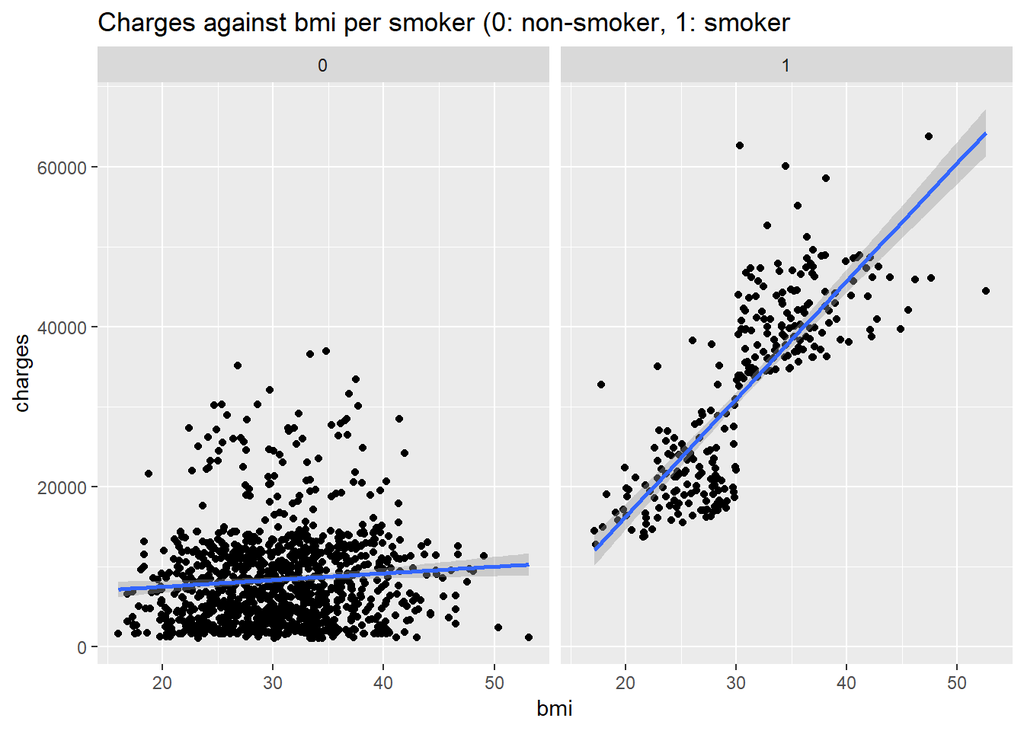

```r
ggplot(data=insurance,
       mapping = aes(y = charges, x= bmi))+ geom_point()+ geom_smooth(method = 'lm') +facet_grid(. ~ smoker) +
  ggtitle("Charges against bmi per smoker (0: non-smoker, 1: smoker")
```

As expected, there seems to be a clear relationship between charges and bmi, considering if a person is smoking or not. Since this relationship makes even sense from the domain perspective, we will definitely keep this in our model.

### 3.5.4 Measure of Fit

In this section, we were able to fit several models, having different levels of complexity. For the following analysis we have chosen our four models to measure the individual fit. Moreover we will compare them among each other to find the most appropriate model for the given insurance dataset.

```r
formula(lm.insurance.all)
```

```
## charges ~ age + sex + bmi + children + smoker + region
```

```r
summary(lm.insurance.all)$r.squared
```

```
## [1] 0.750913
```

```r
summary(lm.insurance.all)$adj.r.squared
```

```
## [1] 0.7494136
```

```r
formula(lm.insurance.1)
```

```
## charges ~ age + bmi + children + smoker
```

```r
summary(lm.insurance.1)$r.squared
```

```
## [1] 0.7496945
```

```r
summary(lm.insurance.1)$adj.r.squared
```

```
## [1] 0.7489434
```

```r
formula(lm.insurance.2)
```

```
## charges ~ age + bmi + children + smoker + age:bmi + age:children +
##     age:smoker + bmi:children + bmi:smoker + children:smoker
```

```r
summary(lm.insurance.2)$r.squared
```

```
## [1] 0.8392491
```

```r
summary(lm.insurance.2)$adj.r.squared
```

```
## [1] 0.8380378
```

```r
formula(lm.insurance.3)
```

```
## charges ~ age + bmi + children + smoker + bmi:smoker
```

```r
summary(lm.insurance.3)$r.squared
```

```
## [1] 0.8388379
```

```r
summary(lm.insurance.3)$adj.r.squared
```

```
## [1] 0.8382329
```

For the comparison we used R-Squared and the adjusted R-Squared to measure the performance of our models. Since the adjusted R-squared can provide a more precise view of that correlation by also taking into account how many independent variables are added to our particular models against we will base our conclusion on this parameter.

Therefore we are happy to state that the latest model number three is able to explain the charges with a percentage of 83.82329 % based on the independent variables.

Comparing the latest model with the first one there is an increase of 8.88% in the adjusted R-squared. Even if the latest model is performing the best compared to the others, it is always a trade off between the gain in the fit and the corresponding effort.

# 4 Polynomial models

As we can see from the following plot, the models are not always linear.

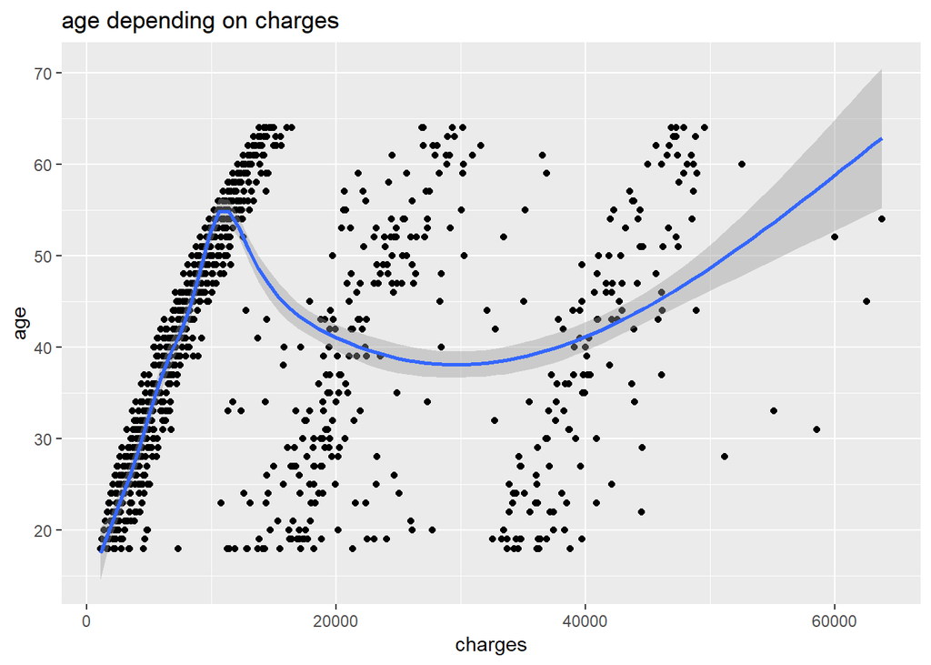

```r
gg.age.charges <- ggplot(data = insurance,
                  mapping = aes (y = age,
                                 x = charges)) +
  geom_point()
gg.age.charges + geom_smooth() + ggtitle("age depending on charges")
```

We add linearity to the model by adding a square term to charges.

```r
# Model with a linear effect for charges
lm.insurance.4 <- lm(age ~ sex + bmi + children + charges, data = insurance)

#Model with a quadratic effect for charges
lm.insurance.5 <- update(lm.insurance.4, . ~ . + I(charges^2))
```

The F-test is used to test the quadrate term.

```r
anova(lm.insurance.4, lm.insurance.5)
```

```
## Analysis of Variance Table
##
## Model 1: age ~ sex + bmi + children + charges
## Model 2: age ~ sex + bmi + children + charges + I(charges^2)
##   Res.Df    RSS Df Sum of Sq      F    Pr(>F)
## 1   1333 239086
## 2   1332 198860  1     40227 269.45 < 2.2e-16 ***
## ---
## Signif. codes:  0 '***' 0.001 '**' 0.01 '*' 0.05 '.' 0.1 ' ' 1
```

The F-test shows a strong indication charges requires a quadratic term.

The graphical result is shown below.

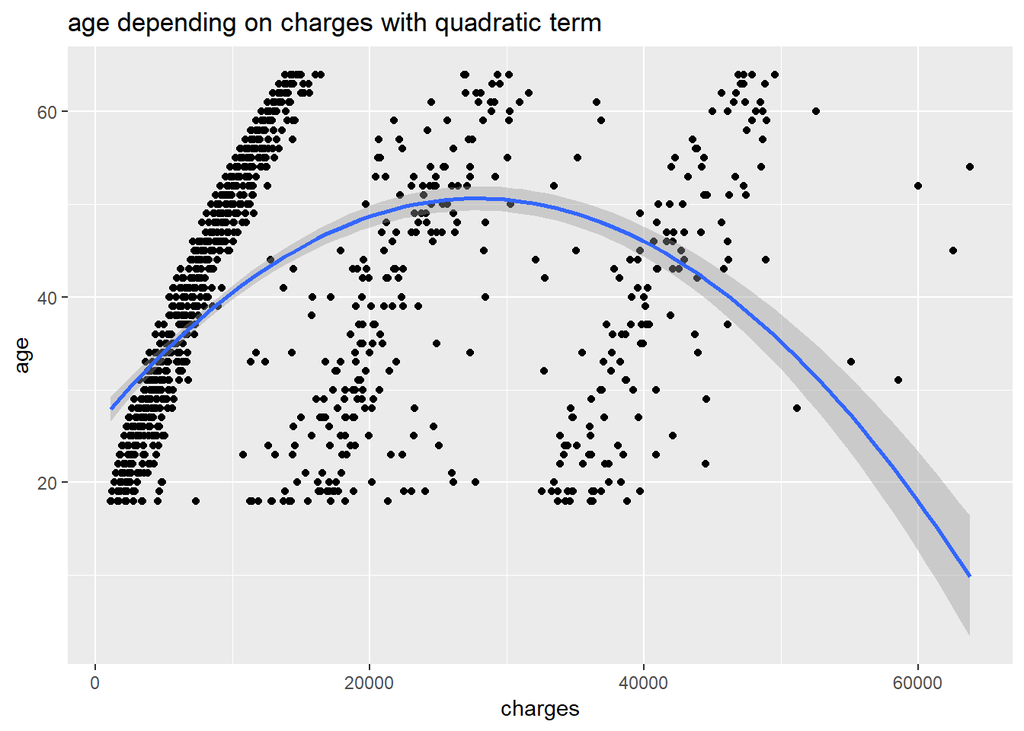

```r
gg.age.charges +
  geom_smooth(method = "lm",
              formula = y ~ poly(x, degree = 2)) +
              ggtitle("age depending on charges with quadratic term")
```

What is the result if you look at the men and women separately.

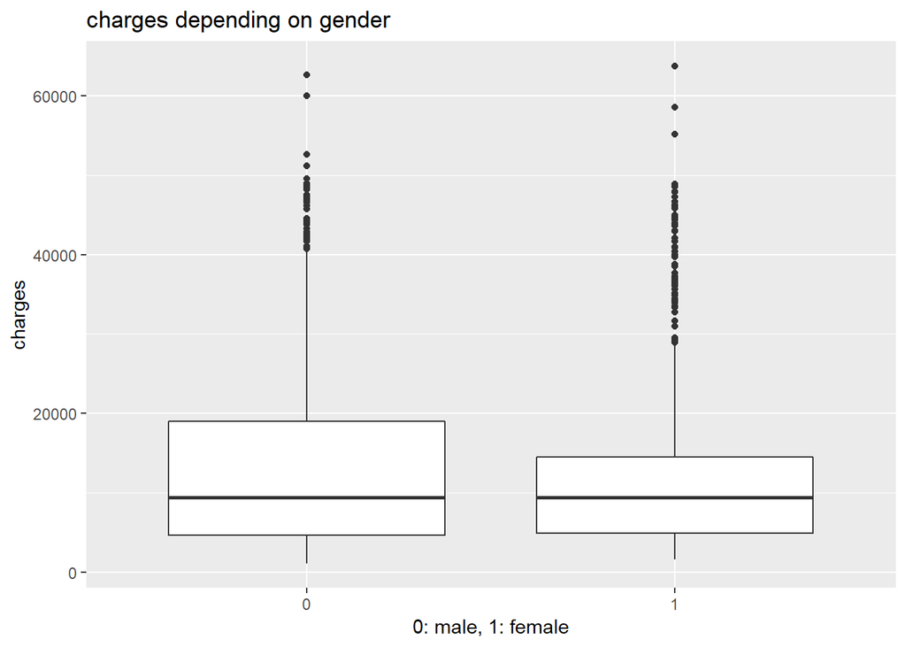

```r
ggplot(data = insurance,
         mapping = aes(y = charges,
                       x = sex)) +
    geom_boxplot() + ggtitle("charges depending on gender")  + xlab("0: male, 1: female")
```

This graph shows that there is not really a difference in the median between women and men. The only difference is in the middle 50% range where the men have a larger range.

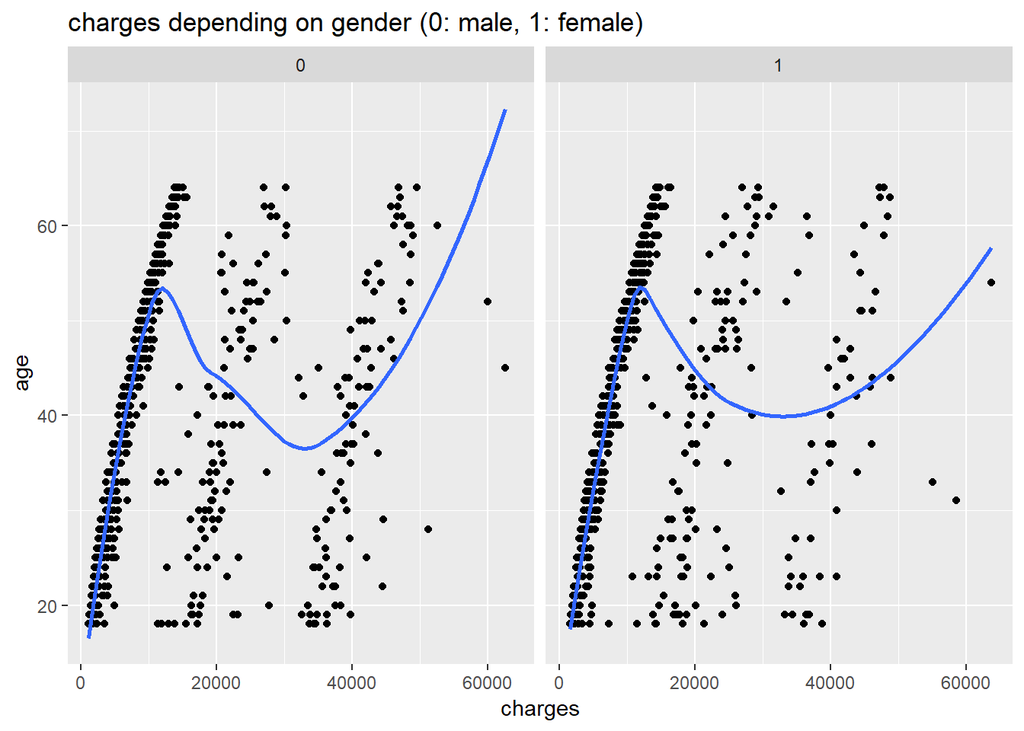

```r
ggplot(data = insurance,
       mapping = aes(y = age,
                     x = charges)) +
  geom_point() +
  geom_smooth(se = FALSE) +
  facet_wrap(. ~ sex) + ggtitle("charges depending on gender (0: male, 1: female)")
```

The rough course of costs as a function of age is comparable for men and women. A closer look at the result reveals slight differences. However, this is not a reason to differentiate the models according to gender.

The first cost increase looks more like a linear model. What does the result look like if the costs are brought above 18’000? This will be examined in the following considerations.

```r
insurance.part2 <- filter(insurance, charges > 18000 )
```

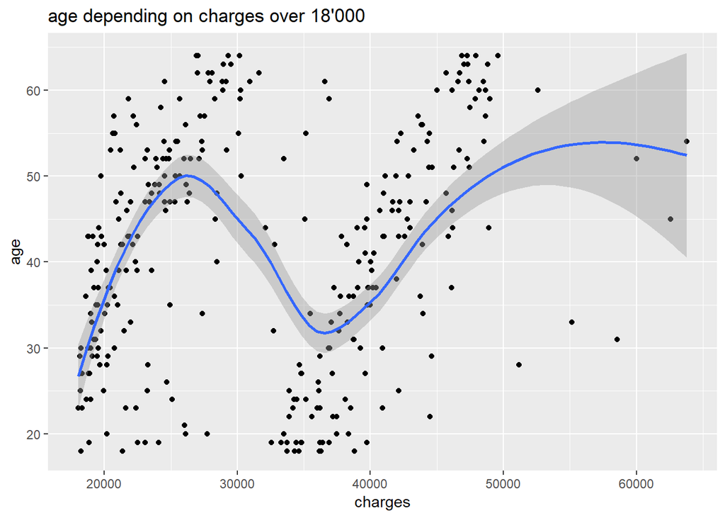

```r
gg.age.charges.part2 <- ggplot(data = insurance.part2,
                              mapping = aes (y = age,
                                             x = charges)) +
  geom_point()
gg.age.charges.part2 + geom_smooth() + ggtitle("age depending on charges over 18'000")
```

```r
lm.insurance.11 <- lm(age ~ sex + bmi + children +charges, data = insurance.part2)
lm.insurance.12 <- update(lm.insurance.11, . ~ . + I(charges^2))

anova(lm.insurance.11, lm.insurance.12)
```

```
## Analysis of Variance Table
##
## Model 1: age ~ sex + bmi + children + charges
## Model 2: age ~ sex + bmi + children + charges + I(charges^2)
##   Res.Df   RSS Df Sum of Sq      F Pr(>F)
## 1    308 53277
## 2    307 52872  1    405.12 2.3523 0.1261
```

The result shows that there is no strong evidence that charges needs a quadratic term. The model appears to be linear.

# 5 Generalised Additive Models

The previous data modelling is now performed with GAM.

```r
gam.insurance.1 <- gam(age ~ sex + s(charges) + children,
                       data = insurance)
summary(gam.insurance.1)
```

```
##
## Family: gaussian
## Link function: identity
##
## Formula:
## age ~ sex + s(charges) + children
##
## Parametric coefficients:
##             Estimate Std. Error t value Pr(>|t|)
## (Intercept)  41.1364     0.3598 114.330  < 2e-16 ***
## sex1         -1.0849     0.4186  -2.591  0.00966 **
## children     -1.2719     0.1836  -6.926 6.72e-12 ***
## ---
## Signif. codes:  0 '***' 0.001 '**' 0.01 '*' 0.05 '.' 0.1 ' ' 1
##
## Approximate significance of smooth terms:
##              edf Ref.df     F p-value
## s(charges) 8.974      9 363.9  <2e-16 ***
## ---
## Signif. codes:  0 '***' 0.001 '**' 0.01 '*' 0.05 '.' 0.1 ' ' 1
##
## R-sq.(adj) =   0.71   Deviance explained = 71.3%
## GCV = 57.673  Scale est. = 57.157    n = 1338
```

The s(charges) value of 8,974 is high and allows us to model the existing predictor with a smooth term. The corresponding visualization is shown below.

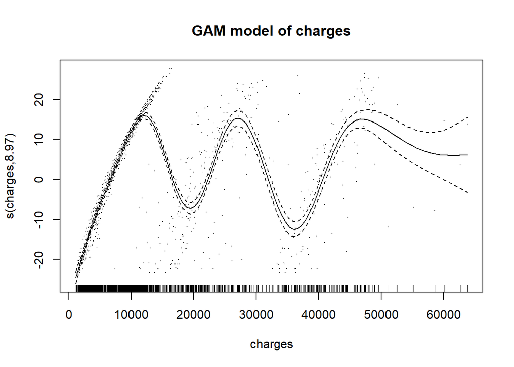

```r
plot(gam.insurance.1, residuals = TRUE, select = 1, main = "GAM model of charges")
```

```r
gam.insurance.2 <- gam(age ~ sex + s(charges) + children,
                       data = insurance.part2)
summary(gam.insurance.2)
```

```
##
## Family: gaussian
## Link function: identity
##
## Formula:
## age ~ sex + s(charges) + children
##
## Parametric coefficients:
##             Estimate Std. Error t value Pr(>|t|)
## (Intercept)  41.5861     0.9591  43.360   <2e-16 ***
## sex1         -0.1992     1.1457  -0.174    0.862
## children     -0.2804     0.4936  -0.568    0.570
## ---
## Signif. codes:  0 '***' 0.001 '**' 0.01 '*' 0.05 '.' 0.1 ' ' 1
##
## Approximate significance of smooth terms:
##              edf Ref.df     F p-value
## s(charges) 8.815   8.99 32.15  <2e-16 ***
## ---
## Signif. codes:  0 '***' 0.001 '**' 0.01 '*' 0.05 '.' 0.1 ' ' 1
##
## R-sq.(adj) =  0.474   Deviance explained = 49.2%
## GCV =  101.7  Scale est. = 97.857    n = 313
```

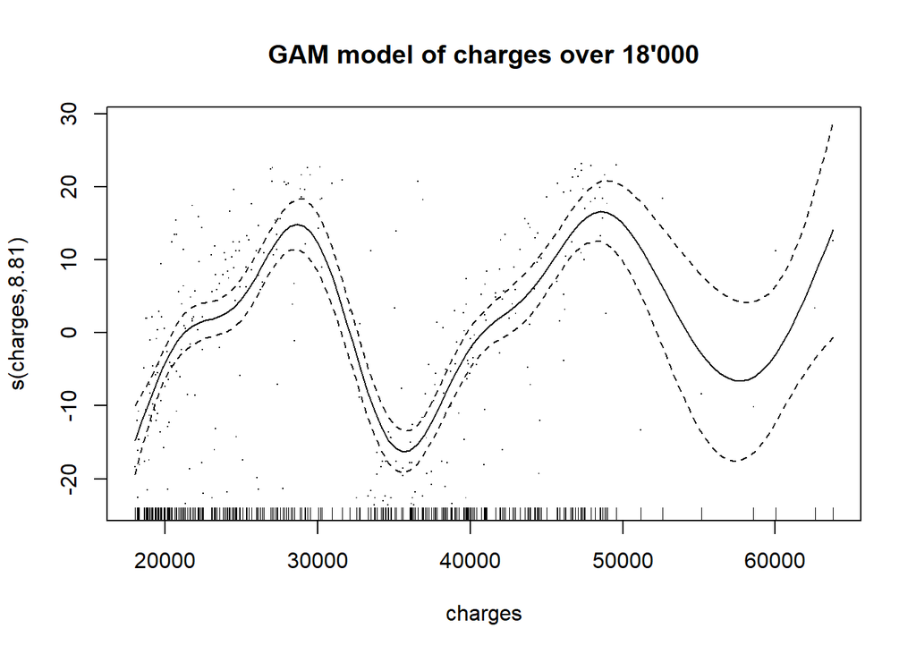

```r
plot(gam.insurance.2, residuals = TRUE, select = 1, main = "GAM model of charges over 18'000")
```

# 6 Generalised Linear Models

## 6.1 Generalised Linear Models for count data

### 6.1.1 Original data

The number of children an insured person has is analysed. We have the following data on children per person. The number of children ranges from 0 to 5 with a median of 1.

```r
summary(insurance$children)
```

```
##    Min. 1st Qu.  Median    Mean 3rd Qu.    Max.
##   0.000   0.000   1.000   1.095   2.000   5.000
```

### 6.1.2 Poisson model

To model count data (number of children) the poisson model is used. An analysis performed beforehand showed that only the variables “charges” and “smoker” have a significant impact on the number of children.

```r
glm.children <- glm(children ~ smoker+charges,
                   data=insurance,
                   family = "poisson")
summary(glm.children)
```

```
##
## Call:
## glm(formula = children ~ smoker + charges, family = "poisson",
##     data = insurance)
##
## Deviance Residuals:
##     Min       1Q   Median       3Q      Max
## -1.8561  -1.4318  -0.1057   0.7768   2.9717
##
## Coefficients:
##               Estimate Std. Error z value Pr(>|z|)
## (Intercept) -3.706e-02  4.213e-02  -0.880   0.3790
## smoker1     -3.239e-01  1.058e-01  -3.061   0.0022 **
## charges      1.419e-05  3.365e-06   4.217 2.48e-05 ***
## ---
## Signif. codes:  0 '***' 0.001 '**' 0.01 '*' 0.05 '.' 0.1 ' ' 1
##
## (Dispersion parameter for poisson family taken to be 1)
##
##     Null deviance: 2001.6  on 1337  degrees of freedom
## Residual deviance: 1984.1  on 1335  degrees of freedom
## AIC: 3879.4
##
## Number of Fisher Scoring iterations: 5
```

To get the coefficients, the log transformation needs to be reversed:

```r
exp(coef(glm.children))
```

```
## (Intercept)     smoker1     charges
##   0.9636169   0.7233085   1.0000142
```

Smoker (factor): The model shows that for the factor smoker (yes/no), a smoker has on average 72% of the number of children a non-smoker has. The more common-sense interpretation might be the other way around, that people who have 1 or more children smoke less, but for the moment we have no proof of that.

Charges: A person with higher charges will on average have more children. If charges are increased by 1000 dollars, the calculated number of children increases by 1.4%.

### 6.1.3 Simulation of data and comparison

With the calculated model, data is simulated:

```
##      sim_1
##  Min.   :0.000
##  1st Qu.:0.000
##  Median :1.000
##  Mean   :1.102
##  3rd Qu.:2.000
##  Max.   :6.000
```

The original and the simulated data are compared visually. The number of children from the simulated data (0-6) seem to be plausible. The distribution has a strong downwards trend starting at 1 like the original data. However the model does not seem to generate enough data with 0 children.

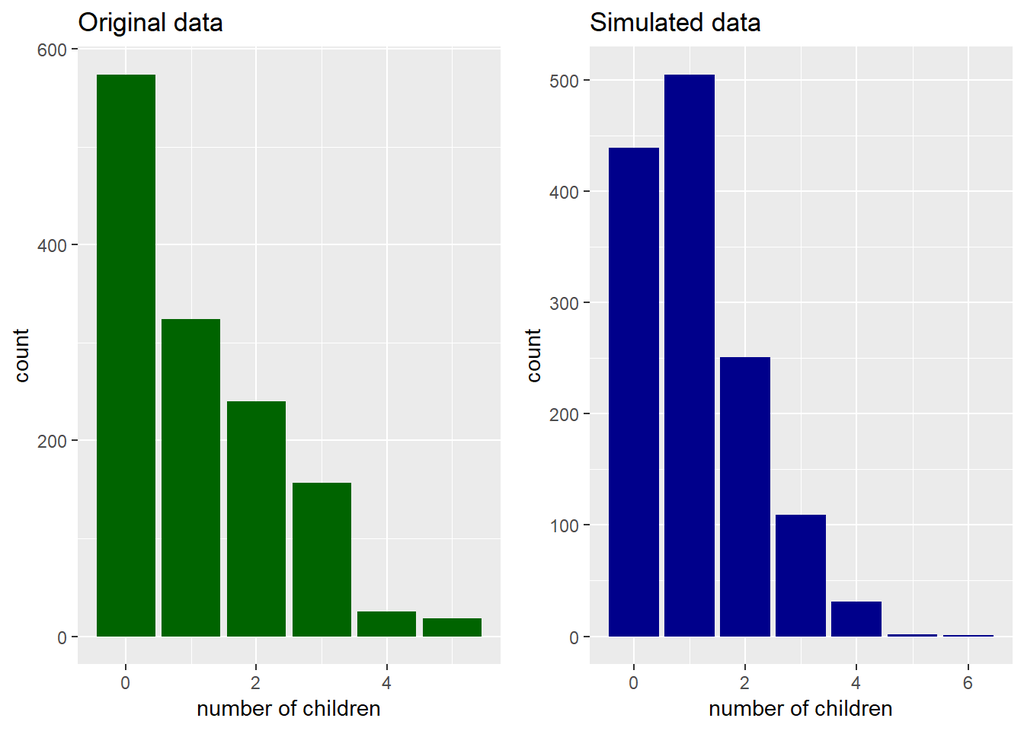

## 6.2 Generalised Linear Models for binomial data

A model is fitted that predicts if a person is a smoker or not. Only the significant values age, bmi and charges are used.

```r
glm.smoker.2 <- glm(smoker ~ age+bmi+charges,
                    data=insurance,
                    family = "binomial")
summary(glm.smoker.2)
```

```
##
## Call:
## glm(formula = smoker ~ age + bmi + charges, family = "binomial",
##     data = insurance)
##
## Deviance Residuals:
##      Min        1Q    Median        3Q       Max
## -3.09442  -0.10998  -0.04475  -0.00970   1.53727
##
## Coefficients:
##               Estimate Std. Error z value Pr(>|z|)
## (Intercept)  5.311e+00  1.029e+00   5.163 2.43e-07 ***
## age         -9.875e-02  1.300e-02  -7.597 3.02e-14 ***
## bmi         -3.481e-01  4.309e-02  -8.078 6.60e-16 ***
## charges      3.822e-04  2.917e-05  13.104  < 2e-16 ***
## ---
## Signif. codes:  0 '***' 0.001 '**' 0.01 '*' 0.05 '.' 0.1 ' ' 1
##
## (Dispersion parameter for binomial family taken to be 1)
##
##     Null deviance: 1356.63  on 1337  degrees of freedom
## Residual deviance:  311.98  on 1334  degrees of freedom
## AIC: 319.98
##
## Number of Fisher Scoring iterations: 8
```

```r
exp(coef(glm.smoker.2))
```

```
## (Intercept)         age         bmi     charges
## 202.5686249   0.9059677   0.7060520   1.0003823
```

Age and bmi has a negative effect on smoker. This means the higher a persons bmi and age, the lower the probability that the person is a smoker. Charges has a positive effect. This means the higher a persons charges, the higher is the possibility that the person smokes.

### 6.2.1 Graphical analysis

This can also be explored graphically, at least for charges it is clearly visible that smokers have higher charges.

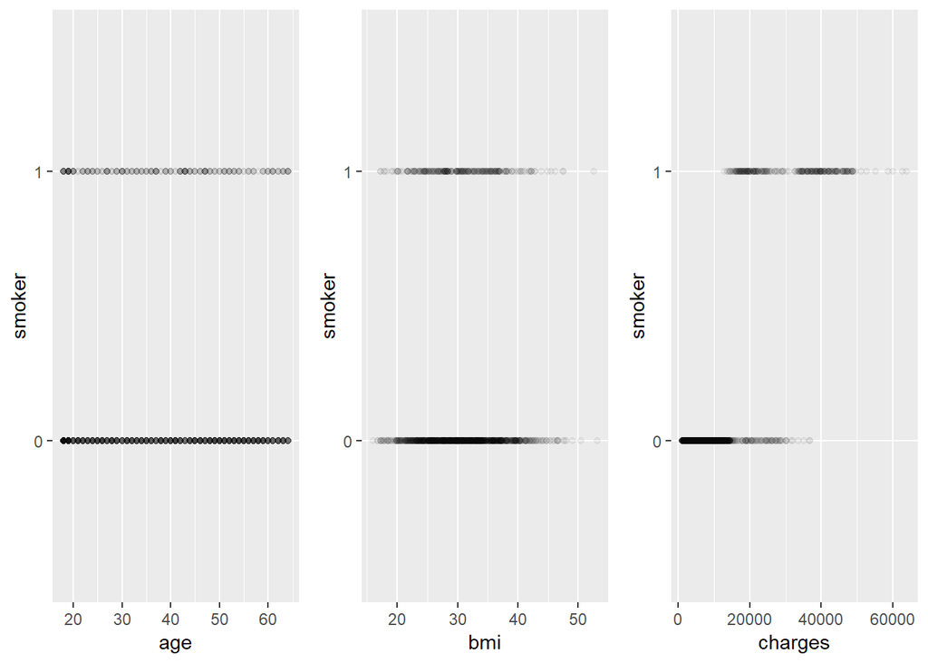

### 6.2.2 Estimating the model performance

The predicted values are transformed into binary (beforehand they inicated the probability) and compared with the actual data.

```r
fitted.smoker.disc <- ifelse(fitted(glm.smoker.2) < 0.5,
                           yes = 0, no = 1)
head(fitted.smoker.disc)
```

```
## 1 2 3 4 5 6
## 1 0 0 1 0 0
```

```r
d.obs.fit.smoker <- data.frame(obs = insurance$smoker,
                             fitted = fitted.smoker.disc)
head(d.obs.fit.smoker)
```

```
##   obs fitted
## 1   1      1
## 2   0      0
## 3   0      0
## 4   0      1
## 5   0      0
## 6   0      0
```

We observe the following fit:

```
##    fit
## obs    0    1
##   0 1028   36
##   1   23  251
```

# 7 Decision Trees

## 7.1 Regression trees

### 7.1.1 Inspecting the Data

To start of with our regression trees, we throw a glance at the continuous variables:

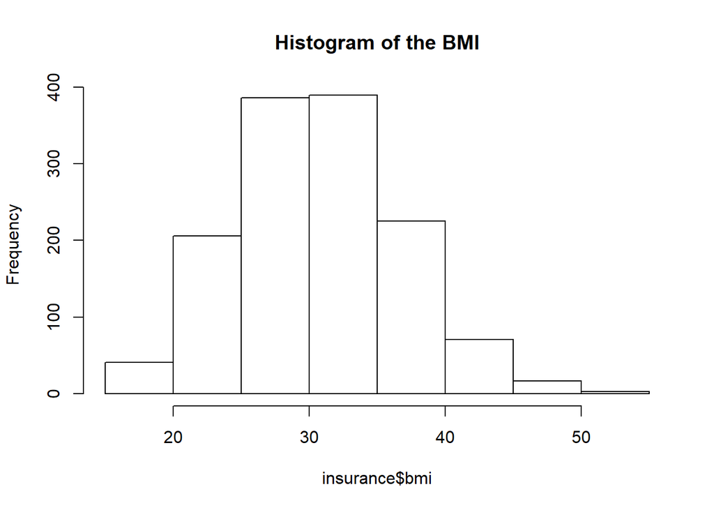

```r
hist(insurance$bmi, main = "Histogram of the BMI")
```

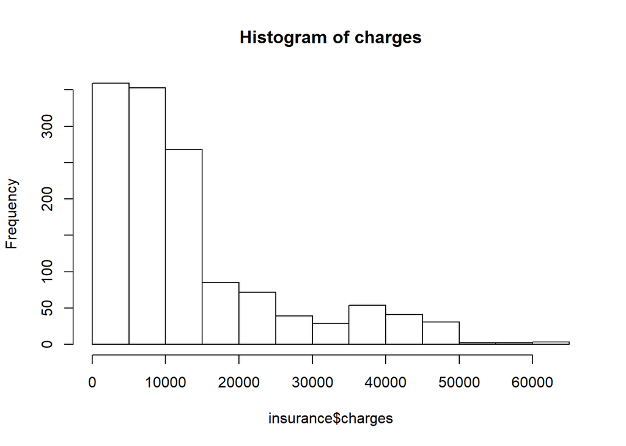

```r
hist(insurance$charges, main = "Histogram of charges")
```

One can see that bmi seems to be normally distributed whereas charges follows the pattern of a 1/x-function.

We thus normalize “charges” by logarithming it. (Attention: Please do only execute the code block (convertion to log) below once as executing it several times will apply the logarithmic function several times)

```r
insurance$charges <- log(insurance$charges)
```

Please note that hence, all charges values for this chapter will strictly be indicated in log-value and not the true one.

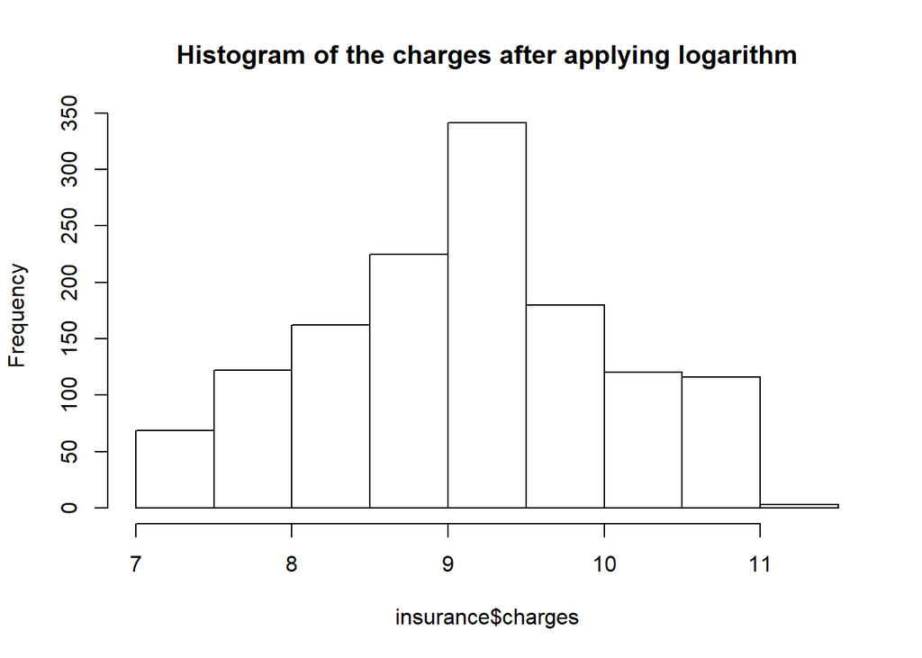

```r
hist(insurance$charges, main = "Histogram of the charges after applying logarithm")
```

Applying a log-transformation solves this issue.

To begin with, we make the rookie mistake to use all the data, which we will then later change by applying a train-test approach. This is done to empasize the importance of not using all the data to train one’s model by showing the differences in methods.

### 7.1.2 Regression tree - BMI

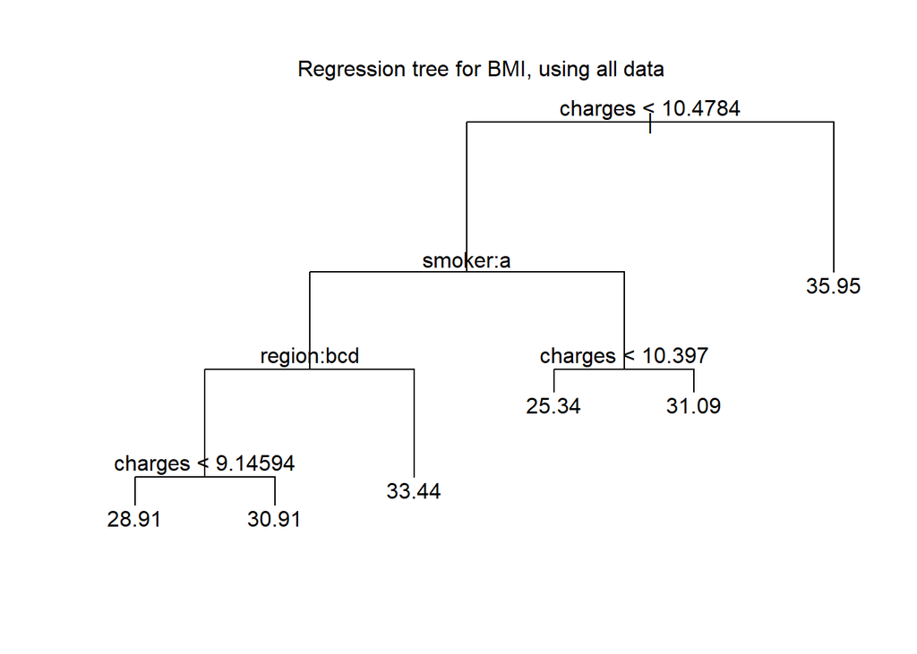

```r
set.seed(99999)
tree.regression.bmi <- tree(bmi~., data=insurance)
plot(tree.regression.bmi)
text(tree.regression.bmi)
mtext("Regression tree for BMI, using all data \n")
```

We here receive a tree with six terminal nodes. Thanks to the tree-function, the tree is already created by recursive binary splitting. As the variables (internal nodes) determining the bmi, “charges” have been applied as well as if one smokes and from which region one comes. This can also be seen in below summary:

```r
summary(tree.regression.bmi)
```

```
##
## Regression tree:
## tree(formula = bmi ~ ., data = insurance)
## Variables actually used in tree construction:
## [1] "charges" "smoker"  "region"
## Number of terminal nodes:  6
## Residual mean deviance:  29.23 = 38930 / 1332
## Distribution of residuals:
##      Min.   1st Qu.    Median      Mean   3rd Qu.      Max.
## -13.09000  -3.62700  -0.07606   0.00000   3.26700  19.69000
```

Our residual mean deviance, aka R-squared-error is at 29.23.

#### 7.1.2.1 Prediction

We here establish a prediction for our bmi tree and also compare the predictions with the true value of the bmi:

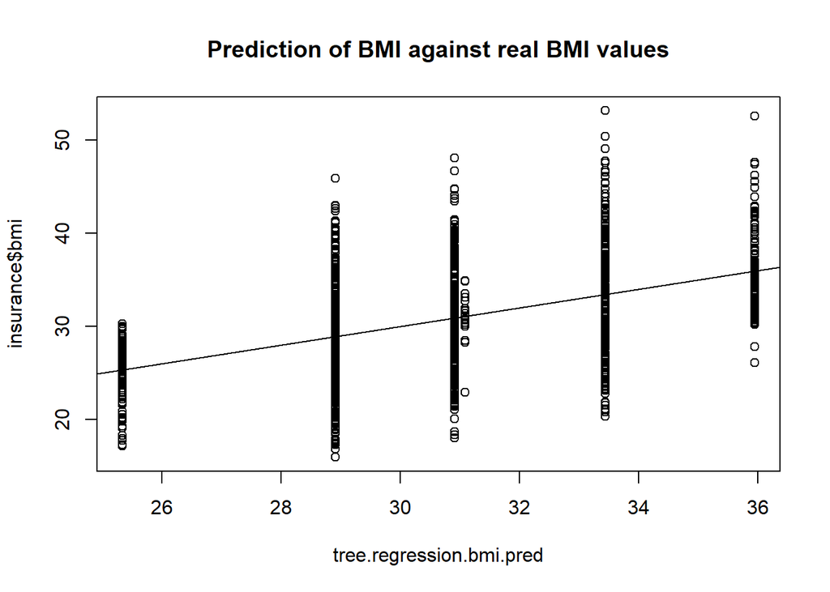

```r
tree.regression.bmi.pred <- predict(tree.regression.bmi, insurance, type="vector")
plot(tree.regression.bmi.pred, insurance$bmi, main = "Prediction of BMI against real BMI values")
abline(0 ,1)
```

We here see how the prediction performs for the bmi values. As one can see, there seem to be rather a fair number of residuals.

#### 7.1.2.2 Comparison of Prediction <-> True Values

Further, we examine the above said residuals:

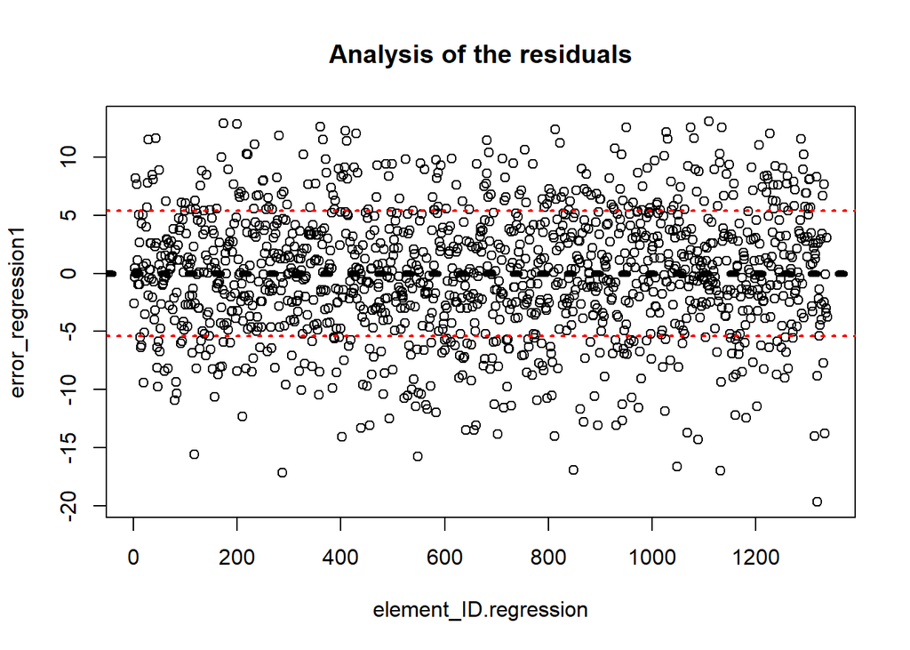

```r
error_regression1 <- tree.regression.bmi.pred-insurance$bmi
element_ID.regression <- 1:length(error_regression1)
plot(element_ID.regression, error_regression1)
title(main="Analysis of the residuals")
abline(0 ,0, lwd=5,lty="dotted")
abline(sd(error_regression1) ,0, lwd=2, col="red", lty="dotted")
abline(-sd(error_regression1) ,0, lwd=2, col="red", lty="dotted")
```

As can be seen, the residual analysis clearly supports the data to be normally distributed. So it is that most of the residuals are distributed fairly symmetrically around 0. A large portion of the residuals is furthermore within the margins of +- 1 standard deviation.

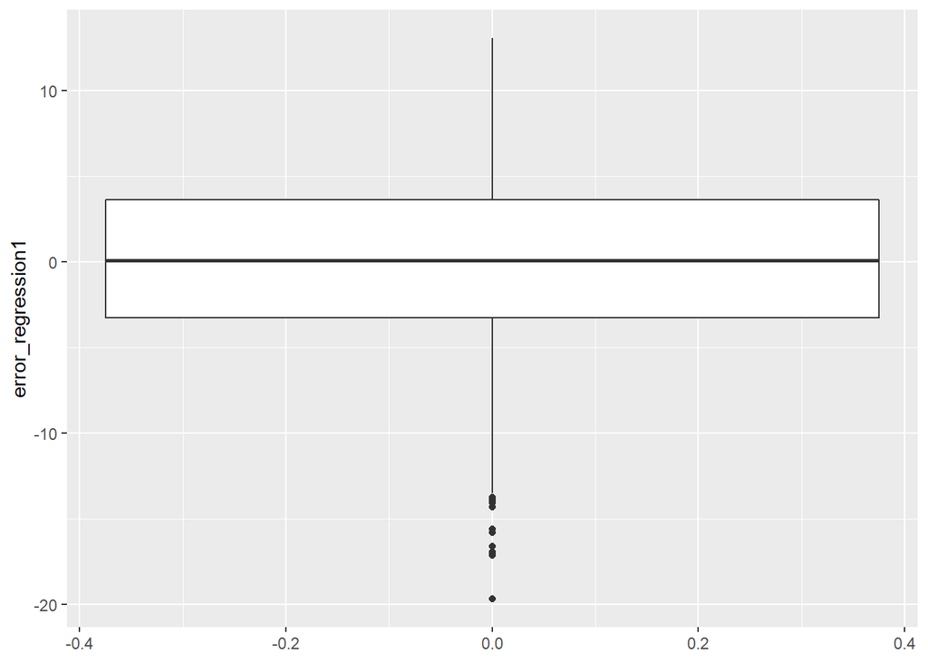

```r
error_regression1_dataframe <- tibble(element_ID.regression, error_regression1)
ggplot(data=error_regression1_dataframe) + geom_boxplot(aes(y=error_regression1))
```

A boxplot further demonstrates the rather normally distributed data with mean around 0. It is apparent for there to be more outliers in the negative y-axis area than the positive y-axis area.

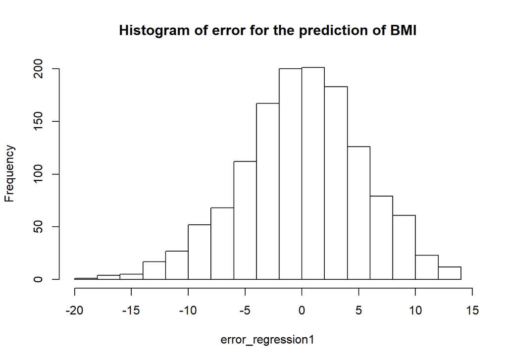

```r
hist(error_regression1, main = "Histogram of error for the prediction of BMI")
```

```r
RSS_bmi <- sum((insurance[3]-tree.regression.bmi.pred)^2)
MSE_bmi <- RSS_bmi/length(tree.regression.bmi.pred)
deviation_bmi <- sqrt(MSE_bmi)
cat(RSS_bmi)
```

```
## 38928.55
```

```r
cat("\n")
```

```r
cat(deviation_bmi)
```

```
## 5.39394
```

So the average estimation of a bmi is about 5.39 bmi points away from the true value.

We now switch to the train-test approach.